# Crisis Watch: What Happens Before It Happens?

Exploring Early Warning Indicators Across Global Economic Shocks (1997 and 2008)

Mohamed Bakkali

June 11, 2025

# 1 Introduction

Understanding how to predict major economic crises before they happen is a key challenge for economists, policymakers, and businesses. In recent decades, the world has experienced several severe financial shocks, such as the Asian Financial Crisis (1997–98) and the Global Financial Crisis (2008), both of which had widespread effects on growth, employment, and financial stability worldwide.

The goal of this project is to investigate which macroeconomic indicators can serve as early warning signals for such crises. By focusing on data visualizations and dashboards, this project aims to make it easier to spot the warning signs that often appear in key economic variables before a crisis hits.

**Why Focus on Macro Indicators?**

Many studies and central banks have shown that certain macroeconomic indicators—such as rapid private credit growth, rising asset prices, or changes in current account balances—often provide early signals of financial distress. For example, Private sector credit booms and increasing money market rates have often preceded banking and currency crises in developed countries *(Babecky et al.,2012)*.

Other example, are the quity prices and the output gap (the difference between actual and potential GDP) are strong leading indicators, especially in advanced economies *(Chen & Svirydzenka, 2021)*.

Moreover, Composite indicators—which combine several macro and financial variables—are more effective at predicting systemic crises than relying on any single indicator alone *(Lo Duca & Peltonen, 2011)*.

This paper builds on these findings by focusing on macroeconomic indicators that are simple to track and visualize. Using dashboards, the paper will display and compare Trends in GDP growth, and indicators as Private sector credit, monetary policy, balances acoount and others.

By visualizing how these indicators evolved in the years leading up to both the Asian and Global Financial Crises, we can be able to answer questions as **Which indicators gave the clearest warning signs? Are there patterns that repeat across different crises? How might monitoring these variables help us prevent or prepare for the next crisis?**

Detecting early warning signals is not just an academic exercise. If policymakers and analysts can spot dangerous trends in time, they can take action to reduce risks and limit the impact of future crises. Interactive dashboards make it easier for anyone as students, analysts, or decision makers to explore and understand these patterns.

By analyzing both emerging-market (Asian Crisis) and advanced-economy (Global Financial Crisis) episodes, this study aims to uncover whether different economies exhibit similar warning patterns or whether early signals are context-specific. This cross crisis comparison enhances the robustness of any lessons drawn.

In this study, we present a comparative dashboard-based analysis of macroeconomic indicators leading up to the Asian and Global Financial Crises. This includes a summary table of key indicator performance to assess their predictive power.

# 2 Asian Crisis 1997–98

The Asian Financial Crisis offers a compelling case study for testing the predictive power of early warning indicators. By examining trends in credit growth, exchange rates, and current account balances, we can observe that signs of vulnerability were present years before the crisis unfolded. This raises an important question: Could these macro financial indicators have been used more effectively at the time to anticipate and mitigate the impact of the crisis? The following section will explores this possibility through visual analysis of key variables across some affected countries.

## 2.1 GDP Growth: A Macroeconomic Lens on Crisis Patterns

To provide a global perspective and set the context for our analysis, we begin by examining the evolution of GDP growth across regions and over time. This overview helps us identify broad economic patterns and turning points that may signal rising vulnerabilities before a crisis emerges.

Gross Domestic Product (GDP) growth is one of the most fundamental indicators of economic health. It shows to us the overall economic activity, capturing shifts in production, consumption, and investment. Monitoring GDP growth across countries provides a macro level lens through which we can detect emerging weaknesses or overheating dynamics.

Taking a global perspective is important because financial crises often spill across borders and reflect not just domestic imbalances but also international linkages through trade, capital flows, and also policy contagion. As *Reinhart and Rogoff (2009)* argue in “This Time is Different”, many crises follow similar macro patterns despite differing local triggers, with declining GDP growth frequently give a signal build-up of financial stress. Furthermore, according to the *IMF (2022)*, synchronized slowdowns in global growth often precede financial distress in both advanced and emerging economies, underlining the need for a comparative, several country approach to early warning analysis.

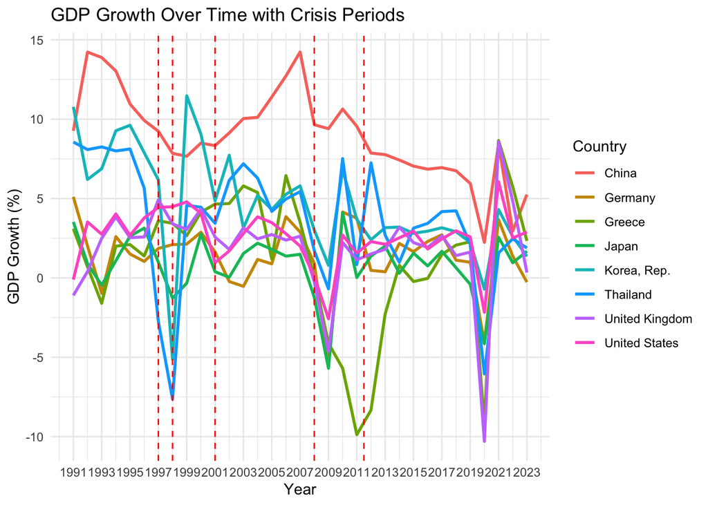

This graph reinforces that GDP growth is more than just a retrospective economic measure—it can act as a lead indicator for identifying vulnerabilities that precede major crises. In the case of the Asian Financial Crisis, declining growth signaled overinvestment and weakening competitiveness. Likewise, prior to the Global Financial Crisis, slowing GDP growth in advanced economies masked underlying financial fragilities tied to debt and housing bubbles. Therefore, in both historical cases, GDP growth helps set the stage for deeper investigation. It’s a first-level signal prompting analysts to dig into credit markets, external balances, and asset prices to understand the systemic risks at play.

In particular, the noticeable drop in GDP growth among Asian economies prior to 1997–98 stands out as a key signal that something was fundamentally wrong beneath the surface. This early trend in growth led us to further examine other critical macroeconomic indicators as private credit expansion, exchange rate regimes, and current account imbalances which ultimately explain how and why the Asian crisis unfolded.

As such, GDP growth is not just a symptom but a gateway metric but it draws attention to deeper structural and financial weaknesses, making it a vital starting point in any early warning framework.

## 2.2 Private Sector Credit Expansion: A Precursor to Financial Stress

Credit to the private sector (% of GDP) is a core macro financial metric that captures the scale of borrowing by households and businesses relative to the economy. Faster credit expansion is widely recognized as a warning sign of financial vulnerability, especially in emerging markets with underdeveloped financial oversight. According to the Bank for *International Settlements (BIS)*,* excessive credit growth when not supported by real economic output can fuel asset bubbles and increase systemic risk. For this reason, credit to GDP is often used in early warning indicator to detect potential crisis conditions before they materialize.

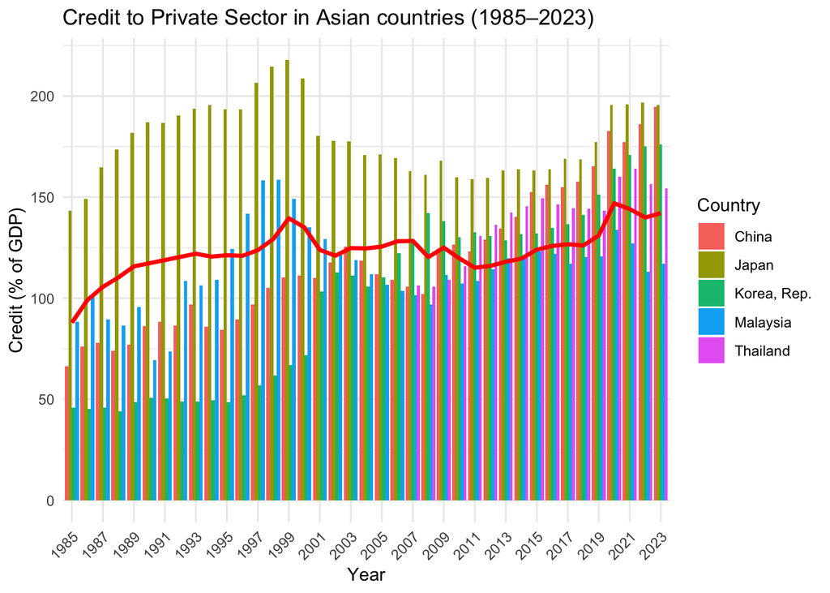

## 2.3 Official Exchange Rates

The official exchange rate indicate how much units of local currency required to buy 1 US dollar. Is a key financial variable in open economies. In countries with fixed or semi fixed exchange rate regimes, sustained pressure on the exchange rate can signal underlying imbalances, such as capital flight, falling reserves, or a loss of investor confidence. According to *Kaminsky, Lizondo, and Reinhart (1998)* researcher, exchange rate misalignments and speculative attacks are among the most consistent early warning indicators for balance of payments and currency crises in emerging markets.

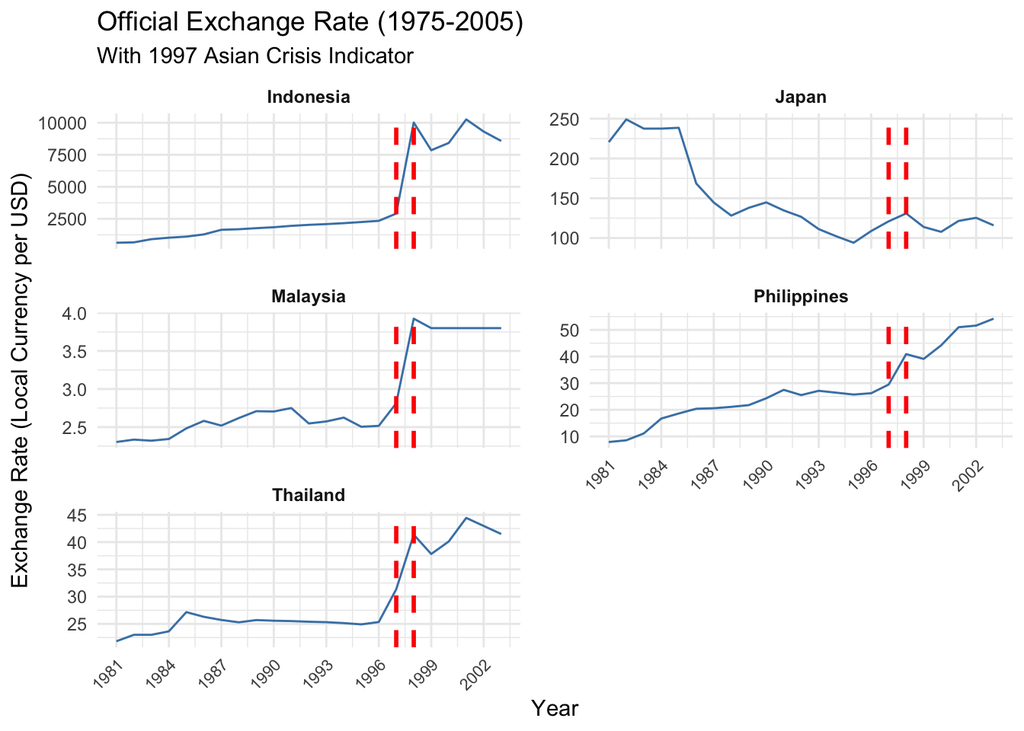

Sharp currency devaluations often happen when a country tries to defend its currency but runs out of foreign reserves. This is exactly what happened to Thailand in 1997, it had to give up its fixed exchange rate, and the baht dropped sharply. After that, other countries like Indonesia, Malaysia, and the Philippines also saw their currencies fall. These shifts in the graph show that when a currency loses value quickly, it can be a strong warning sign that a crisis is starting. In this way, tracking exchange rates especially in countries with fixed or semi fixed systems can help spot early signs of financial trouble.

## 2.4 Assian current account balance

The current account balance measures the difference between a countries exports and imports of goods, services, and capital income. A persistent deficit means the country is spending more than it earns, relying heavily on foreign capital inflows to finance that gap. This becomes risky when the funding comes from short term or speculative “hot money” rather than long-term investment. If investor confidence drops, the capital can leave quickly triggering a sudden stop, currency depreciation, and financial crisis. This is why the *IMF and BIS* classify sustained current account deficits as important early warning indicators in emerging markets.

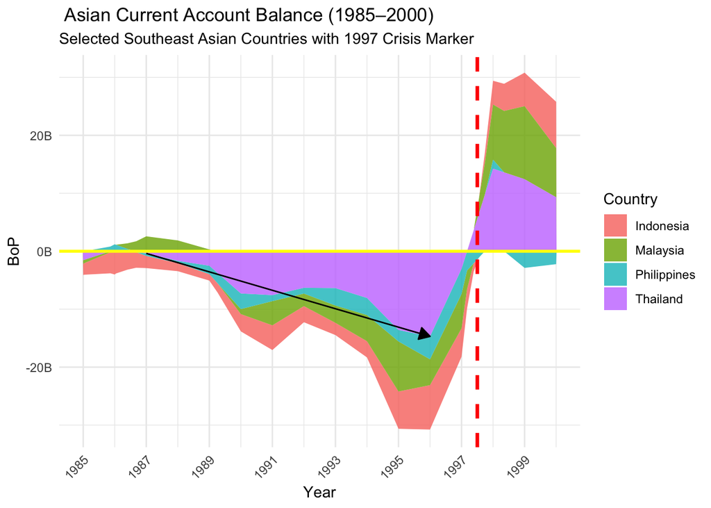

The area plot shows the current account balances of Thailand, Indonesia, Malaysia, and the Philippines from 1985 to 2000. All four countries experienced deepening deficits through the early 1990 s, with Thailand running large deficits for nearly a decade mainly financed by foreign capital inflows. As investor sentiment collapsed in 1997, capital reversed direction, triggering sharp currency devaluations and a rapid external adjustment.

Following the crisis, these economies shifted to surpluses as imports fell, exports gained competitiveness, and spending was reduced which reflected in the graphs upward trend after 1997.

This graph makes clear that large, persistent current account deficits were major warning signs ahead of the Asian crisis. These imbalances left countries like Thailand and Indonesia highly exposed to external shocks. The failure to adjust over time despite growing deficits meant that when investor confidence collapsed, there was no buffer. The sharp reversal to surplus after 1997 highlights how unsustainable those deficits had been. In this way, tracking the current account especially when paired with capital flow data is a valuable early warning tool for identifying external vulnerabilities in emerging markets.

## 2.5 Current Account Balance - Deficits pre-crisis

This table provides a summary of current account balance trends in the years leading up to the Asian Financial Crisis. It highlights each country pre-crisis deficit pattern, the timing of their peak imbalances, and the reversal observed after the crisis.

Current Account - summary table

| Country | Trend (1987–1996) | Peak Deficit Year | Reversal After Crisis | Crisis Signal |
| --- | --- | --- | --- | --- |
| Indonesia | ⬇️ decreasing | 1996 | ✅ Yes | ✅ Yes |
| Malaysia | ⬇️ decreasing | 1995 | ✅ Yes | ✅ Yes |
| Philippines | ⬇️ decreasing | 1997 | ✅ Yes | ✅ Yes |
| Thailand | ⬇️ decreasing | 1996 | ✅ Yes | ✅ Yes |

Together, these results confirm that current account deficits acted as a reliable early warning signal. The fact that all four countries showed sustained deficits before the crisis—and then sharp reversals after—shows how this indicator clearly reflects rising external vulnerability. When analyzed alongside exchange rate movements and credit trends, the current account balance offers a more complete and early view of financial stress in emerging economies.

# 3 Global Financial Crisis 2008

The Global Financial Crisis of 2008 presents a different but equally revealing context for assessing early warning indicators. In contrast to the emerging market nature of the Asian crisis, the global crisis originated in advanced economies, where rising private debt, housing bubbles, and prolonged low interest rates built up systemic risk. This raises the question: Were the warning signs visible in advance, and could a coordinated indicator-based approach have helped detect the looming crisis?

In this section, we analyze the core macro-financial variables that signaled growing fragility in the years before the collapse.

## 3.1 Credit to non financial sector

Credit to the non-financial sector covering households and non-financial corporations, is a key measure of private sector leverage. When credit grows faster than GDP, it often signals that debt is fueling consumption or asset bubbles rather than productive investment.

Depend on the Bank for *International Settlements (BIS)* and studies like *Borio and Lowe (2002)*, excessive credit growth is one of the most reliable early warning indicators of financial crises in advanced economies. The 2008 Global Financial Crisis is a real word example case where unchecked credit expansion played a major role.

[figure not shown]

This indicator clearly meets the criteria for an early warning signal. The sharp rise in credit before 2008 preceded the crisis by several years, matching the theoretical and empirical findings in global financial research. In the context of our study, this credit growth acts as a strong and visible red flag. When combined with other indicators such as housing prices and interest rates, it becomes even more effective at detecting risk in the financial system before the crash happened.

Thus, the sharp rise in debt before the crisis leads us to the next question: what was happening to asset prices?

## 3.2 Residantial Price Index in US

The housing market is a central component of financial stability, especially in advanced economies where real estate is a major source of household wealth and collateral for lending. A rapid rise in house prices especially when disconnected from fundamentals like income or rent can signal a speculative bubble.

According to *Case and Shiller (2003)*, asset bubbles in housing markets are often driven by credit expansion and investor overconfidence, making them a valuable early warning signal. The *IMF (2011)* also includes housing price misalignments as one of the core indicators in systemic risk dashboards.

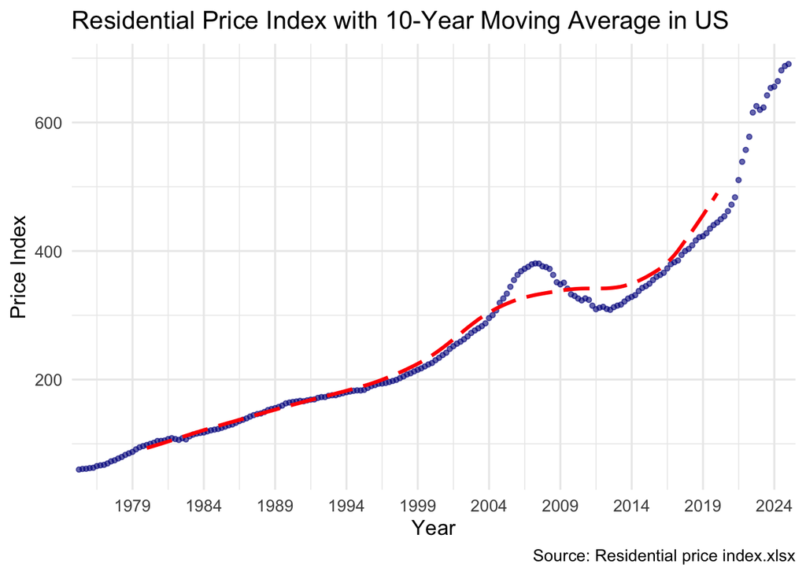

## 3.3 Current Account Balance

The current account balance reflects a countries net trade in goods and services, along with net income and transfers. Persistent deficits can indicate over reliance on foreign capital to finance domestic spending often related to the credit booms and asset bubbles. According to *Reinhart and Rogoff (2009)* and the IMF early warning frameworks, large and sustained current account deficits are strong precursors to financial instability, especially when financed by short-term or speculative inflows.

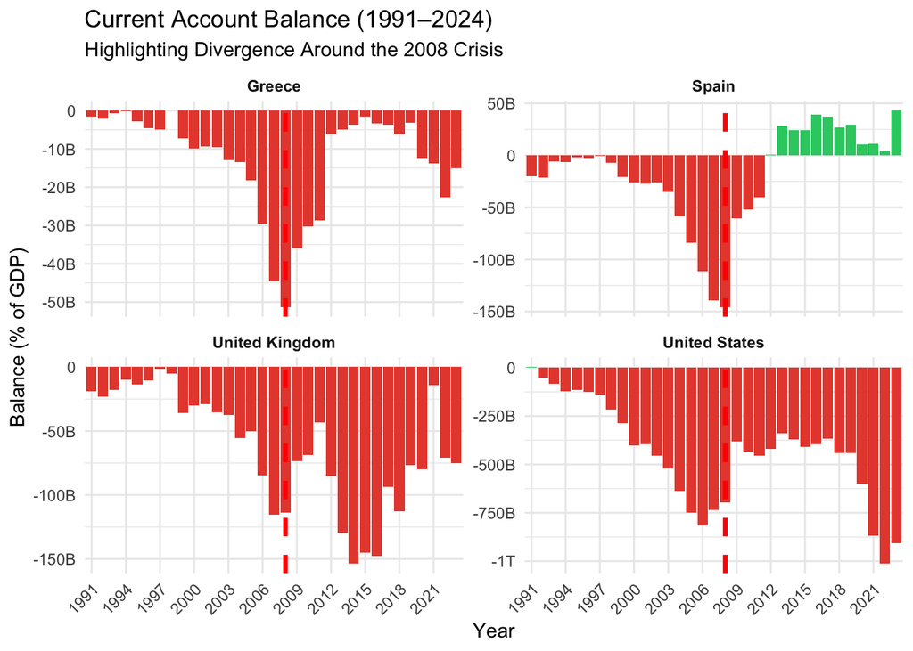

when combined with credit and housing indicators, its become a really good signed to estimate an upcoming crisis. These current account deficits reflected underlying excess consumption, overborrowing, and global imbalances. The dramatic corrections after the crisis, especially in Spain and Greece, confirm that their deficits were unsustainable.

Therefore, the pre 2008 widening gaps in external balances offer another important signal of rising systemic risk one that, if tracked in real-time, could have served as an early warning of the coming crisis.

## 3.4 Central bank policy US

Central bank interest rates are a key tool of monetary policy, influencing borrowing costs, credit growth, and asset prices. When rates are kept too low for too long, they can incentivize excessive risk-taking, contribute to credit bubbles, and inflate asset prices. According to *Taylor (2009)*, the Federal Reserve low interest rate policy in the early 2000s played a central role in fueling the U.S. housing bubble. Monetary conditions, especially in advanced economies, are thus considered an important early warning component in financial stability frameworks *(IMF, 2011)*.

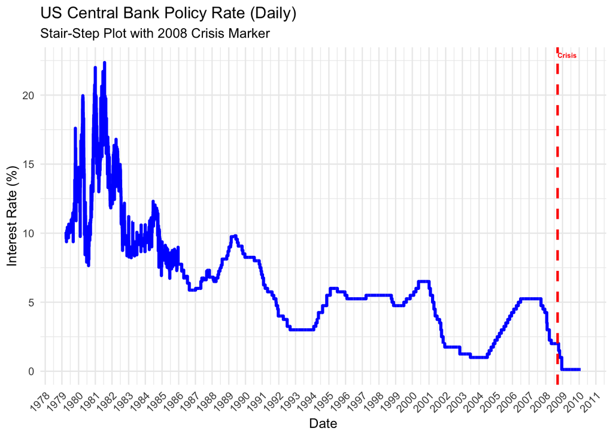

The stair step plot displays the US Federal Funds Rate from 1979 to 2011. After the aggressive monetary tightening in the 1980s, interest rates entered a long-term downward trend, reaching historically low levels in the early 2000s.

In this study, the policy rate trend serves as a supporting indicator highlighting how easy monetary conditions contributed to the environment that led to the crisis.

# 4 Conclusion

To conclude this analysis, we return to our central question: Can early warning indicators help detect financial crises before they occur? Based on visual investigations of two major crises—the Asian Financial Crisis of 1997–98 and the Global Financial Crisis of 2008—we observe that key macro-financial signals did, in fact, appear well before each collapse. These signals were visible through trends in GDP growth, credit expansion, exchange rates, current account balances, housing prices, and monetary policy rates.

To summarize these findings, the following heatmap offers a comparative overview of early warning indicators across countries and crisis episodes. It highlights not just which indicators were present but also how consistently they signaled risk in different environments.

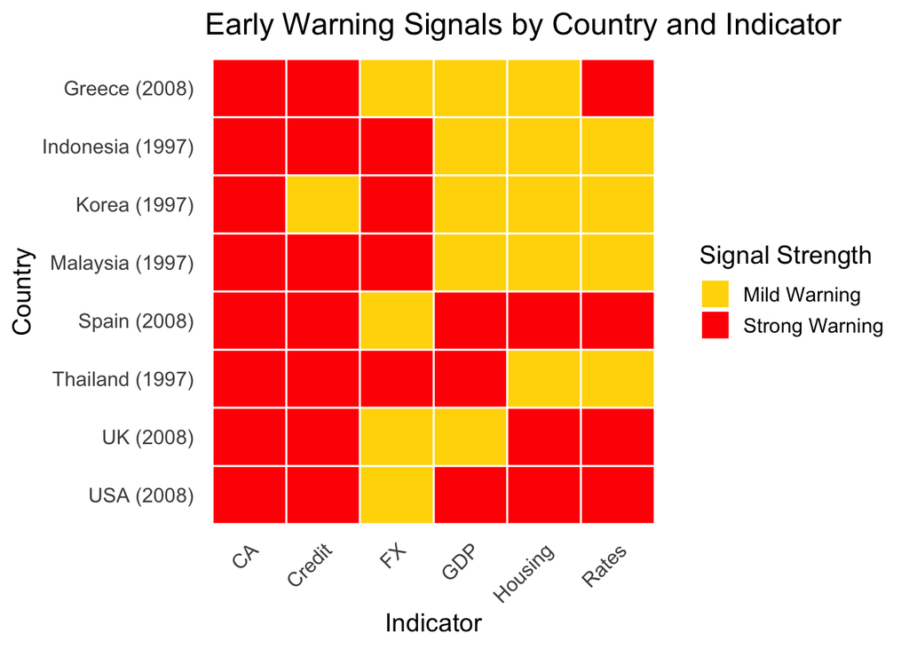

The heatmap reveals a compelling pattern: no single indicator alone was sufficient, but multiple indicators flashing at once provided a clear early warning in nearly every case. In both crises, countries that experienced a combination of rapid credit growth, persistent current account deficits, and asset price distortions—often under loose monetary conditions—were the most exposed.

This supports the conclusion that an integrated early warning system, based on a dashboard of macro-financial indicators, can significantly improve our ability to detect systemic risks. While the exact timing of a crisis may remain uncertain, the buildup of vulnerabilities is often visible in advance. Recognizing these patterns—through regular monitoring and comparative analysis—can help policymakers, analysts, and institutions act sooner to prevent or mitigate future crises.

While this study demonstrates the value of early warning indicators in anticipating financial crises, it is important to acknowledge its limitations. One key constraint is the frequency and availability of data. Many of the indicators analyzed—such as current account balances or credit to the private sector—are only available at annual intervals, which limits the ability to capture short-term dynamics or sudden shifts. In contrast, higher-frequency data (e.g., monthly or quarterly) would allow for more precise monitoring and faster detection of emerging risks. Expanding access to such data in future research would improve the sensitivity and timeliness of early warning systems.

# 5 References

- Babecký, J., Havránek, T., Matějů, J., Rusnák, M., Šmídková, K., & Vašíček, B. (2012). *[Banking, Debt and Currency Crises: Early Warning Indicators for Developed Countries](https://www.ecb.europa.eu/pub/pdf/scpwps/ecbwp1485.pdf)*. ECB Working Paper Series, No. 1485.
- Borio, C., & Lowe, P. (2002). *[Asset Prices, Financial and Monetary Stability: Exploring the Nexus](https://www.bis.org/publ/work114.pdf)*. BIS Working Papers, No. 114.
- Case, K. E., & Shiller, R. J. (2003). *[Is There a Bubble in the Housing Market?](https://www.brookings.edu/wp-content/uploads/2003/06/2003b_bpea_case.pdf)*. Brookings Papers on Economic Activity, 2003(2), 299–362.
- Chen, S., & Svirydzenka, K. (2021). *[Systemic Risk Indicators and Macroprudential Policy: A New Database](https://www.imf.org/-/media/Files/Publications/WP/2021/English/wpiea2021116-print-pdf.ashx)*. IMF Working Paper No. 21/105.
- International Monetary Fund (IMF). (2011). *[Macroprudential Policy: An Organizing Framework](https://www.imf.org/external/np/pp/eng/2011/031411.pdf)*. IMF Policy Paper, Washington, D.C.
- International Monetary Fund (IMF). (2022). *[World Economic Outlook: Countering the Cost-of-Living Crisis](https://www.imf.org/en/Publications/WEO/Issues/2022/10/11/world-economic-outlook-october-2022)*. Washington, D.C.
- Kaminsky, G. L., Lizondo, S., & Reinhart, C. M. (1998). *[Leading Indicators of Currency Crises](https://www.elibrary.imf.org/view/journals/001/1998/079/article-A001-en.xml)*. IMF Staff Papers, 45(1), 1–48.
- Lo Duca, M., & Peltonen, T. A. (2011). *[Macro-Financial Vulnerabilities and Future Financial Stress: Assessing Systemic Risks and Predicting Systemic Events](https://www.ecb.europa.eu/pub/pdf/scpwps/ecbwp1311.pdf)*. ECB Working Paper Series, No. 1311.
- Reinhart, C. M., & Rogoff, K. S. (2009). *This Time is Different: Eight Centuries of Financial Folly*. Princeton University Press.
- Taylor, J. B. (2009). *[Getting Off Track: How Government Actions and Interventions Caused, Prolonged, and Worsened the Financial Crisis](https://www.hoover.org/research/getting-track)*. Hoover Institution Press.
- World Bank. *[World Development Indicators](https://databank.worldbank.org/source/world-development-indicators)*. Accessed via World Bank Open Data.
- Bank for International Settlements (BIS). *[Credit to the Non-Financial Sector](https://www.bis.org/statistics/totcredit.htm)*. BIS Statistics and Research.